# R markdown: Identificación y comparación de secuencias de multimorbilidad longitudinales por sexo en la Base Poblacional de Salud de Andalucía

Soledad Pérez Sánchez

2024-05-11

## Librerías

Instalamos las librerías:

```r
library(dbnR)
library(bnlearn)
library(data.table)
library(readxl)
library(visNetwork)
library(igraph)
library(dplyr)
library(factoextra)
library(leiden)
library(knitr)
library(kableExtra)
library(gridExtra)
library(ggplot2)
```

## Datos

Cargamos los datos:

```r
# Cargamos los datos:
dat_mujeres <- read_excel("data_mujeres.xlsx")
dat_hombres <- read_excel("data_hombres.xlsx")
# Eliminamos la primera columna (es el identificador):
dat_mujeres <- dat_mujeres[-1]
dat_hombres <- dat_hombres[-1]

# Mostramos algunos valores:
dat_mujeres[1:5, 1:5]
```

```
## # A tibble: 5 × 5
##       HIV `Colon cancer` `Thyroid cancer` `Breast cancer` `Uterine cancer`
##     <dbl>          <dbl>            <dbl>           <dbl>            <dbl>
## 1 0.00783        0.00626          0.00626          0.0470          0.00470
## 2 0.00313        0.00313          0.00157          0.0470          0.00626
## 3 0.00626        0.00626          0.00940          0.0407          0.00157
## 4 0.00313        0.00157          0.00157          0.0423          0.00470
## 5 0              0.00783          0.00470          0.0454          0.00313
```

```r
dat_hombres[1:5, 1:5]
```

```
## # A tibble: 5 × 5
##       HIV `Hair and neck cancer` `Stomach cancer` `Colon cancer`
##     <dbl>                  <dbl>            <dbl>          <dbl>
## 1 0.00738                0.00443          0.00148        0.00295
## 2 0.00443                0.00295          0.00295        0.00148
## 3 0.0103                 0.00886          0.00148        0.00148
## 4 0.00738                0.00148          0.00295        0.00591
## 5 0.00443                0.00738          0              0.00591
## # ℹ 1 more variable: `Pancreatic cancer` <dbl>
```

```r
# Diferentes tamaños de size:
sizes <- c(2:20)
```

## Construcción de los modelos:

### Mujeres

```r
# Lista para almacenar los resultados de cada modelo:
# modelos_mujeres <- list()

# Creación de los modelos:
for (size in sizes) {

  # Iniciamos el contador de tiempo:
  t <- proc.time()

  # Entrenamos el modelo:
  modelo <- dbnR::learn_dbn_struc(dat_mujeres, size, method = "dmmhc", intra=T)

  # Preparamos de los datos para validación cruzada:
  dat_fdt <- fold_dt(dat_mujeres, size)

  # Cálculo del tiempo de entrenamiento:
  t_dmmhc <- proc.time() - t

  # Medición de la fuerza de los arcos:
  arc_strength <- arc.strength(modelo, dat_fdt, criterion="mi-g")
  arcs <- modelo$arcs
  arcs <- gsub("_t_.*", "", arcs)
  arcs_df <- as.data.frame(arcs)

  # Almacenamos los resultados en la lista:
  modelos_mujeres[[paste0("size_", size)]] <- list(
    "model" = modelo,
    "folded_data" = dat_fdt,
    "arc_strength" = arc_strength,
    "arcs_df" = arcs_df,
    "training_time" = t_dmmhc
  )
}
save(modelos_mujeres, file = "modelos_mujeres.RData")
```

```r
load("modelos_mujeres.RData")
```

### Hombres

```r
# Lista para almacenar los resultados de cada modelo:
#modelos_hombres <- list()

# Creación de los modelos:
for (size in sizes) {

  # Iniciamos el contador de tiempo:
  t <- proc.time()

  # Entrenamos el modelo:
  modelo <- dbnR::learn_dbn_struc(dat_hombres, size, method = "dmmhc", intra=T)

  # Preparamos de los datos para validación cruzada:
  dat_fdt <- fold_dt(dat_hombres, size)

  # Cálculo del tiempo de entrenamiento:
  t_dmmhc <- proc.time() - t

  # Medición de la fuerza de los arcos:
  arc_strength <- arc.strength(modelo, dat_fdt, criterion="mi-g")
  arcs <- modelo$arcs
  arcs <- gsub("_t_.*", "", arcs)
  arcs_df <- as.data.frame(arcs)

  # Almacenamos los resultados en la lista:
  modelos_hombres[[paste0("size_", size)]] <- list(
    "model" = modelo,
    "folded_data" = dat_fdt,
    "arc_strength" = arc_strength,
    "arcs_df" = arcs_df,
    "training_time" = t_dmmhc
  )
}
save(modelos_hombres, file = "modelos_hombres.RData")
```

```r
load("modelos_hombres.RData")
```

#### Resultados redes bayesianas dinámicas

```r
enf_muj_totales <- colnames(dat_mujeres)
enf_hom_totales <- colnames(dat_hombres)
enf_hom_totales[which(enf_hom_totales == "ParkinsonÂ´s disease")] <- "Parkinson´s disease"
## parkinson está mal escrito en hombres, pero aparece en mujeres y hombres
enfermedades_totales <- unique(c(enf_muj_totales, enf_hom_totales))
setdiff(enfermedades_totales, enf_hom_totales)
```

```
## [1] "Uterine cancer"  "Cervical cancer" "Ovarian cancer"
```

```r
setdiff(enfermedades_totales, enf_muj_totales)
```

```
## [1] "Prostatic cancer"  "Testicular cancer"
```

```r
enfermedades_totales <- as.data.frame(enfermedades_totales)
colnames(enfermedades_totales) <- "Enfermedades"
kable(enfermedades_totales, format = "html", align = "l") %>%
       kable_styling(full_width = F)
```

| Enfermedades |
| --- |
| HIV |
| Colon cancer |
| Thyroid cancer |
| Breast cancer |
| Uterine cancer |
| Cervical cancer |
| Ovarian cancer |
| Hodgkin’s disease |
| Leukemia |
| Diabetes |
| Dyslipidemia |
| Hypothyroidism |
| Obesity |
| Other organic mental disorder |
| Alcohol dependence |
| Tobacco dependence |
| Psychosis |
| Mood disorder |
| Anxiety |
| Eating disorder |
| Other Functional Disorder |
| Personality and behavior disorder in adults |
| Intellectual disability |
| Epilepsy |
| Extrapyramidal syndrome |
| Neurological disease with non-stroke motor deficit |
| Glaucoma |
| Retinopathy |
| Cerebrovascular disease, ill-defined |
| Occlusion or stenosis of precerebral arteries |
| Cerebrovascular disease sequel |
| Extremity arterial disease |
| Atrial fibrillation |
| Ischemic heart disease |
| Acquired valvulopathy |
| Congenital cardiac and circulatory anomaly |
| Hypertension |
| Heart failure |
| COPD |
| Asthma |
| Liver disease (except cirrhosis) |
| Hepatic steatosis |
| Cirrhosis |
| Gastroesophageal reflux disease |
| Regional enteritis and ulcerative colitis |
| Malabsorption syndrome and food intolerance |
| Psoriasis |
| Osteoporosis |
| Osteoarthritis, spondylosis |
| Gout and other arthropathies due to crystals |
| Other arthropathy |
| Rheumatoid arthritis |
| Collagen disease and vasculitis |
| Fibromyalgia |
| Renal failure |
| Urinary lithiasis |
| Childhood-adolescent onset disorder |
| Atopic dermatitis |
| Substance dependence, other |
| Bladder cancer |
| Dementia |
| Artery aneurysm |
| Age-related macular degeneration |
| Renal cancer |
| Parkinson´s disease |
| Skin melanoma |
| Non-Hodgkin lymphoma |
| Lung cancer |
| Other developmental disorder |
| Liver cancer |
| Pancreatic cancer |
| Inmunoproliferative cancer |
| Hair and neck cancer |
| Bone and soft tissue cancer |
| Intra-abdominal arterial disease |
| Stomach cancer |
| Kaposi’s Sarcoma |
| Autism Spectrum Disorder |
| Prostatic cancer |
| Testicular cancer |

```r
info_mujeres <- data.frame(Size = numeric(), Nodos = numeric(), Asociaciones = numeric(), Enfermedades = numeric(), Tiempo = numeric())
for (i in seq_along(sizes)) {
  size <- paste0("size_", sizes[i])
  asoc <- dim(modelos_mujeres[[size]][["model"]][["arcs"]])[1]
  enf <- length(unique(c(modelos_mujeres[[size]][["arcs_df"]]$from,
                         modelos_mujeres[[size]][["arcs_df"]]$to)))
  nodos <- length(modelos_mujeres[[size]][["model"]][["nodes"]])
  tiempo <- modelos_mujeres[[size]][["training_time"]][["user.self"]] +
            modelos_mujeres[[size]][["training_time"]][["sys.self"]]
  fila <- data.frame(Size = sizes[i], Asociaciones = asoc, Nodos = nodos, Enfermedades = enf, Tiempo = tiempo)
  info_mujeres <- rbind(info_mujeres, fila)
}

info_hombres <- data.frame(Size = numeric(), Asociaciones = numeric(), Nodos = numeric(), Enfermedades = numeric(), Tiempo = numeric())
for (i in seq_along(sizes)) {
  size <- paste0("size_", sizes[i])
  asoc <- dim(modelos_hombres[[size]][["model"]][["arcs"]])[1]
  enf <- length(unique(c(modelos_hombres[[size]][["arcs_df"]]$from,
                         modelos_hombres[[size]][["arcs_df"]]$to)))
  nodos <- length(modelos_hombres[[size]][["model"]][["nodes"]])
  tiempo <- modelos_hombres[[size]][["training_time"]][["user.self"]] +
            modelos_hombres[[size]][["training_time"]][["sys.self"]]
  fila <- data.frame(Size = sizes[i], Asociaciones = asoc, Nodos = nodos, Enfermedades = enf, Tiempo = tiempo)
  info_hombres <- rbind(info_hombres, fila)
}
```

```r
kable(info_mujeres, format = "html") %>%
    add_header_above(c("Modelos en Mujeres" = 5)) %>%
  kable_styling(bootstrap_options = c("striped", "hover", "condensed"), full_width = F) %>%
  column_spec(1, bold = TRUE)
```

| Modelos en Mujeres Size | Modelos en Mujeres Asociaciones | Modelos en Mujeres Nodos | Modelos en Mujeres Enfermedades | Modelos en Mujeres Tiempo |
| --- | --- | --- | --- | --- |
| 2 | 187 | 156 | 73 | 7.199 |
| 3 | 295 | 234 | 75 | 32.848 |
| 4 | 400 | 312 | 77 | 99.528 |
| 5 | 498 | 390 | 77 | 233.392 |
| 6 | 613 | 468 | 78 | 467.095 |
| 7 | 715 | 546 | 78 | 859.359 |
| 8 | 812 | 624 | 77 | 1433.080 |
| 9 | 911 | 702 | 77 | 2260.628 |
| 10 | 1000 | 780 | 77 | 3358.047 |
| 11 | 1103 | 858 | 78 | 5112.464 |
| 12 | 1190 | 936 | 78 | 5899.406 |
| 13 | 1303 | 1014 | 78 | 6397.469 |
| 14 | 1415 | 1092 | 78 | 8325.087 |
| 15 | 1506 | 1170 | 78 | 13529.541 |
| 16 | 1598 | 1248 | 78 | 14126.311 |
| 17 | 1702 | 1326 | 78 | 17684.466 |
| 18 | 1792 | 1404 | 78 | 26607.394 |
| 19 | 1877 | 1482 | 78 | 33503.793 |
| 20 | 1963 | 1560 | 78 | 35726.730 |

```r
kable(info_hombres, format = "html") %>%
  add_header_above(c("Modelos en Hombres" = 5)) %>%
  kable_styling(bootstrap_options = c("striped", "hover", "condensed"), full_width = F) %>%
  column_spec(1, bold = TRUE)
```

| Modelos en Hombres Size | Modelos en Hombres Asociaciones | Modelos en Hombres Nodos | Modelos en Hombres Enfermedades | Modelos en Hombres Tiempo |
| --- | --- | --- | --- | --- |
| 2 | 174 | 154 | 72 | 4.337 |
| 3 | 267 | 231 | 77 | 19.173 |
| 4 | 364 | 308 | 76 | 57.341 |
| 5 | 449 | 385 | 76 | 137.364 |
| 6 | 533 | 462 | 76 | 281.075 |
| 7 | 621 | 539 | 77 | 556.015 |
| 8 | 724 | 616 | 77 | 899.335 |
| 9 | 812 | 693 | 77 | 1409.357 |
| 10 | 885 | 770 | 77 | 2144.148 |
| 11 | 953 | 847 | 77 | 3414.893 |
| 12 | 1046 | 924 | 77 | 4851.013 |
| 13 | 1126 | 1001 | 77 | 5874.508 |
| 14 | 1236 | 1078 | 77 | 7869.870 |
| 15 | 1320 | 1155 | 77 | 10384.417 |
| 16 | 1427 | 1232 | 77 | 13220.638 |
| 17 | 1493 | 1309 | 77 | 16711.261 |
| 18 | 1577 | 1386 | 77 | 21075.228 |
| 19 | 1639 | 1463 | 77 | 26001.066 |
| 20 | 1692 | 1540 | 77 | 31699.369 |

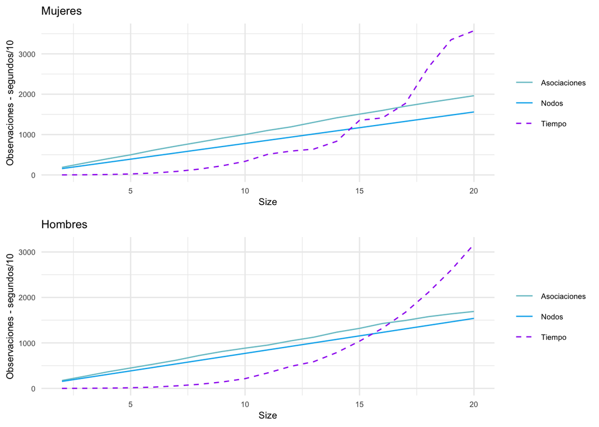

```r
# Grafico para mujeres
grafico_mujeres <- ggplot(info_mujeres) +
  geom_line(aes(x = Size, y = Asociaciones, color = "Asociaciones"), size = 0.5) +
  geom_line(aes(x = Size, y = Nodos, color = "Nodos"), size = 0.5) +
  labs(x = "Size", y = "Observaciones - segundos/10",
       title = "Mujeres") +
  geom_line(aes(x = Size, y = Tiempo/10, color = "Tiempo"), size = 0.5, linetype = "dashed") +
  scale_color_manual(values = c("Asociaciones" = "cadetblue3", "Nodos" = "deepskyblue2", "Tiempo" = "purple")) +
  theme_minimal() +
  theme(text = element_text(size = 8)) +
  guides(colour = guide_legend(title = NULL))
# Grafico para hombres
grafico_hombres <- ggplot(info_hombres) +
  geom_line(aes(x = Size, y = Asociaciones, color = "Asociaciones"), size = 0.5) +
  geom_line(aes(x = Size, y = Nodos, color = "Nodos"), size = 0.5) +
  labs(x = "Size", y = "Observaciones - segundos/10",
       title = "Hombres") +
  geom_line(aes(x = Size, y = Tiempo/10, color = "Tiempo"), size = 0.5, linetype = "dashed") +
  scale_color_manual(values = c("Asociaciones" = "cadetblue3", "Nodos" = "deepskyblue2", "Tiempo" = "purple")) +
  theme_minimal() +
  theme(text = element_text(size = 8)) +
  guides(colour = guide_legend(title = NULL))

grid.arrange(grafico_mujeres, grafico_hombres, nrow = 2)
```

## Cálculo de las asociaciones

### Mujeres

Creamos un dataframe que contenga todas las asociaciones presentes para los diferentes tamaños de size:

```r
asociaciones_muj <- data.frame()
for (i in seq_along(sizes)) {
  size <- paste0("size_", sizes[i])
  arcs_df <- modelos_mujeres[[size]][["arc_strength"]]
  arcs_df$weights <- (1 - arcs_df$strength) * 1000
  arcs_df$from <- gsub("_t_.*", "", arcs_df$from)
  arcs_df$to <- gsub("_t_.*", "", arcs_df$to)
  arcs_df$arcs <- paste(arcs_df$from, arcs_df$to, sep = "|")
  arcs_df <- arcs_df[,4:5]
  arcs_df <- arcs_df %>%
    group_by(arcs) %>%
    summarise(weights = sum(weights)) # las asociaciones que estén repetidas en un mismo tamaño,
                                      # se agregarán para el cálculo del peso de esa asociación
  asociaciones_muj <- rbind(asociaciones_muj, arcs_df)
}
```

### Hombres

Lo mismo para los hombres:

```r
asociaciones_hom <- data.frame()
for (i in seq_along(sizes)) {
  size <- paste0("size_", sizes[i])
  arcs_df <- modelos_hombres[[size]][["arc_strength"]]
  arcs_df$weights <- (1 - arcs_df$strength) * 1000
  arcs_df$from <- gsub("_t_.*", "", arcs_df$from)
  arcs_df$to <- gsub("_t_.*", "", arcs_df$to)
  arcs_df$arcs <- paste(arcs_df$from, arcs_df$to, sep = "|")
  arcs_df <- arcs_df[,4:5]
  arcs_df <- arcs_df %>%
    group_by(arcs) %>%
    summarise(weights = sum(weights)) # las asociaciones que estén repetidas en un mismo tamaño,
                                      # se agregarán para el cálculo del peso de esa asociación
  asociaciones_hom <- rbind(asociaciones_hom, arcs_df)
}
```

## Asociaciones únicas

```r
length(unique(asociaciones_muj$arcs))
```

```
## [1] 712
```

```r
length(unique(asociaciones_hom$arcs))
```

```
## [1] 714
```

## Filtros en las asociaciones

Vamos a crear una función que aplique los diferentes filtros a cada conjunto de datos y sus asociaciones, con el porcentaje de sizes que queramos.

Los filtros aplicados serán:

Filtro 1: Se seleccionan las asociaciones que estén presentes en el porcentaje de veces de sizes que queramos. Los pesos asociados a estas asociaciones serán el promedio de los pesos de esa asociación para los diferentes tamaños de sizes.

Filtro 2: Se eliminan aquellas asociaciones que establezcan a una enfermedad como causa de sí misma.

Filtro 3: Se eliminan las asociaciones bidireccionales (se guardarán en otro dataframe para poder comentarlas posteriormente).

Filtro 4: Se eliminan el resto de asociaciones que producen un ciclo.

Posteriormente, a partir de las asociaciones filtradas se construirá la red, y se agruparán los nodos utilizando el algoritmo Kmeans y Leiden.

```r
# Creamos la función calculo_asociaciones
calculo_asociaciones <- function(datos, asociaciones, porcentaje) {
  # Calculamos la transpuesta de los datos para que las observaciones sean las enfermedades:
  datos <- t(datos)

  # Filtro 1:
  num_sizes <- ceiling((porcentaje / 100) * length(sizes))
  asociaciones_filtro1 <- table(asociaciones$arcs) >= num_sizes
  asociaciones_filtro1 <- as.data.frame(names(asociaciones_filtro1[asociaciones_filtro1]))
  colnames(asociaciones_filtro1) <- "arcs"
  asociaciones_filtro1 <- subset(asociaciones, arcs %in% asociaciones_filtro1$arcs)
  weights_promedio <- aggregate(weights ~ arcs, data = asociaciones_filtro1, FUN = mean)

  # Se crea el dataframe que será el final con las asociaciones separadas:
  asociaciones_resultado <- data.frame(from = sapply(strsplit(weights_promedio$arcs,
                                                              split = "|",
                                                              fixed = TRUE), "[[", 1),
                                    to = sapply(strsplit(weights_promedio$arcs,
                                                         split = "|",
                                                         fixed = TRUE), "[[", 2),
                                    stringsAsFactors = FALSE)
  asociaciones_resultado$weights <- weights_promedio$weights

  # Filtro 2:
  asociaciones_resultado <- subset(asociaciones_resultado, from != to)

  # Filtro 3:
  asociaciones_bidireccionales <- asociaciones_resultado
  asociaciones_bidireccionales$from <- asociaciones_resultado$to
  asociaciones_bidireccionales$to <- asociaciones_resultado$from
  asociaciones_bidireccionales <- rbind(asociaciones_resultado, asociaciones_bidireccionales)
  asociaciones_bidireccionales <-
    asociaciones_bidireccionales[duplicated(asociaciones_bidireccionales[c("from", "to")]), ]
  asociaciones_bidireccionales <-
    asociaciones_resultado[asociaciones_resultado$from %in% asociaciones_bidireccionales$from
                           & asociaciones_resultado$to %in% asociaciones_bidireccionales$to, ]
  asociaciones_resultado <- subset(asociaciones_resultado,
                                   !(from %in% asociaciones_bidireccionales$from
                                     & to %in% asociaciones_bidireccionales$to))


  # Cálculo de las enfermedades (nodos) presentes para esos sizes y de los datos teniendo en cuenta
  # sólo esas enfermedades.
  nodos <- unique(c(unique(asociaciones_resultado$from), unique(asociaciones_resultado$to)))
  datos_filtrados <- subset(datos, rownames(datos) %in% nodos)
  nodos <- as.data.frame(rownames(datos_filtrados))

  # Dibujo de la red:
  grafo <- graph_from_data_frame(asociaciones_resultado[, -3], directed = TRUE, vertices = nodos)

  # Filtro 4
  while (!is_dag(grafo)) {
  n <- vcount(grafo)
  visitado <- rep(FALSE, n)
  en_pila <- rep(FALSE, n)
  ciclo <- NULL
  dfs <- function(node, path) {
    if (visitado[node]) {
      if (en_pila[node]) {
        ciclo <<- path[which(path == node):length(path)]
      }
      return()
    }
    visitado[node] <<- TRUE
    en_pila[node] <<- TRUE
    for (vecino in neighbors(grafo, node)) {
      dfs(vecino, c(path, vecino))
      if (!is.null(ciclo)) return()
    }
    en_pila[node] <<- FALSE
  }

  for (i in 1:n) {
    if (!visitado[i]) {
      dfs(i, i)
      if (!is.null(ciclo)) break
    }
  }

  nombres_ciclo <- vertex_attr(grafo, "name")[ciclo]
  enfermedades_concatenadas <- sapply(1:(length(nombres_ciclo) - 1), function(i) {
    paste(nombres_ciclo[i], nombres_ciclo[i + 1], sep = "|")
  })

  asociaciones_resultado <- asociaciones_resultado
  asociaciones_filtro4 <- paste(asociaciones_resultado$from, asociaciones_resultado$to, sep = "|")
  asociaciones_filtro4 <- as.data.frame(asociaciones_filtro4)
  asociaciones_filtro4$weights <- asociaciones_resultado$weights

  asociaciones_ciclo <-
    asociaciones_filtro4[asociaciones_filtro4$asociaciones_filtro4 %in% enfermedades_concatenadas, ]
  asociacion_menor <- asociaciones_ciclo[which.min(asociaciones_ciclo$weights), 1]

  asociaciones_filtro4 <- subset(asociaciones_filtro4, asociaciones_filtro4 != asociacion_menor)
  pesos <- asociaciones_filtro4$weights

  asociaciones_filtro4 <- data.frame(
    from = sapply(strsplit(asociaciones_filtro4$asociaciones_filtro4,
                           split = "|",
                           fixed = TRUE),
                  "[[", 1),
    to = sapply(strsplit(asociaciones_filtro4$asociaciones_filtro4,
                         split = "|",
                         fixed = TRUE),
                "[[", 2),
    stringsAsFactors = FALSE)

  asociaciones_filtro4$weights <- pesos

  asociaciones_resultado <- asociaciones_filtro4

  nodos <- unique(c(unique(asociaciones_resultado$from), unique(asociaciones_resultado$to)))
  datos_filtrados <- subset(datos, rownames(datos) %in% nodos)
  nodos <- as.data.frame(rownames(datos_filtrados))

  grafo <- graph_from_data_frame(asociaciones_resultado[, -3], directed = TRUE, vertices = nodos)
  }

  # Le añadimos los pesos al grafo
  E(grafo)$weight <- asociaciones_resultado[, 3]

  # Guardamos algunos resultados
  list(arcos = asociaciones_resultado, nodos = nodos,
       asociaciones_bidereccionales = asociaciones_bidireccionales, grafo = grafo)
}
```

## Dibujo de los grafos

```r
porc <- seq(0, 100, by = 5)
tablas_red_muj <- data.frame(Porcentaje = numeric(), Asociaciones = numeric(), Nodos = numeric()
                             )
for (i in porc) {
  red <- calculo_asociaciones(dat_mujeres, asociaciones_muj, i)
  num = i
  asoc <- dim(red$arcos)[1]
  nod <- dim(red$nodos)[1]
  fila <- data.frame(Porcentaje = i, Asociaciones = asoc, Nodos = nod)
  tablas_red_muj <- rbind(tablas_red_muj, fila)
}


tablas_red_hom <- data.frame(Porcentaje = numeric(), Asociaciones = numeric(), Nodos = numeric())
for (i in porc) {
  red <- calculo_asociaciones(dat_hombres, asociaciones_hom, i)
  num = i
  asoc <- dim(red$arcos)[1]
  nod <- dim(red$nodos)[1]
  fila <- data.frame(Porcentaje = i, Asociaciones = asoc, Nodos = nod)
  tablas_red_hom <- rbind(tablas_red_hom, fila)
}
```

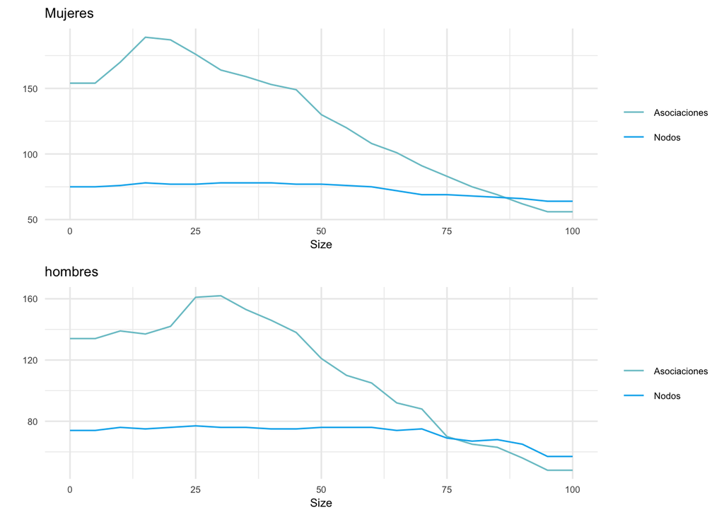

```r
# Grafico para mujeres
grafico_mujeres <- ggplot(tablas_red_muj) +
  geom_line(aes(x = Porcentaje, y = Asociaciones, color = "Asociaciones"), size = 0.5) +
  geom_line(aes(x = Porcentaje, y = Nodos, color = "Nodos"), size = 0.5) +
  labs(x = "Size", y=' ', title = "Mujeres") +
  scale_color_manual(values = c("Asociaciones" = "cadetblue3", "Nodos" = "deepskyblue2")) +
  theme_minimal() +
  theme(text = element_text(size = 8)) +
  guides(colour = guide_legend(title = NULL))

# Grafico para hombres
grafico_hombres <- ggplot(tablas_red_hom) +
  geom_line(aes(x = Porcentaje, y = Asociaciones, color = "Asociaciones"), size = 0.5) +
  geom_line(aes(x = Porcentaje, y = Nodos, color = "Nodos"), size = 0.5) +
  labs(x = "Size", y = " ", title = "hombres") +
  scale_color_manual(values = c("Asociaciones" = "cadetblue3", "Nodos" = "deepskyblue2")) +
  theme_minimal() +
  theme(text = element_text(size = 8)) +
  guides(colour = guide_legend(title = NULL))

grid.arrange(grafico_mujeres, grafico_hombres, nrow = 2)
```

```r
kable(tablas_red_muj[-1,], format = "html", row.names = FALSE) %>%
    add_header_above(c("Resultados en Mujeres" = 3)) %>%
  kable_styling(bootstrap_options = c("striped", "hover", "condensed"), full_width = F) %>%
  column_spec(1, bold = TRUE)
```

| Resultados en Mujeres Porcentaje | Resultados en Mujeres Asociaciones | Resultados en Mujeres Nodos |
| --- | --- | --- |
| 5 | 154 | 75 |
| 10 | 170 | 76 |
| 15 | 189 | 78 |
| 20 | 187 | 77 |
| 25 | 176 | 77 |
| 30 | 164 | 78 |
| 35 | 159 | 78 |
| 40 | 153 | 78 |
| 45 | 149 | 77 |
| 50 | 130 | 77 |
| 55 | 120 | 76 |
| 60 | 108 | 75 |
| 65 | 101 | 72 |
| 70 | 91 | 69 |
| 75 | 83 | 69 |
| 80 | 75 | 68 |
| 85 | 69 | 67 |
| 90 | 62 | 66 |
| 95 | 56 | 64 |
| 100 | 56 | 64 |

```r
kable(tablas_red_hom[-1,], format = "html", row.names = FALSE) %>%
    add_header_above(c("Resultados en Hombres" = 3)) %>%
  kable_styling(bootstrap_options = c("striped", "hover", "condensed"), full_width = F) %>%
  column_spec(1, bold = TRUE)
```

| Resultados en Hombres Porcentaje | Resultados en Hombres Asociaciones | Resultados en Hombres Nodos |
| --- | --- | --- |
| 5 | 134 | 74 |
| 10 | 139 | 76 |
| 15 | 137 | 75 |
| 20 | 142 | 76 |
| 25 | 161 | 77 |
| 30 | 162 | 76 |
| 35 | 153 | 76 |
| 40 | 146 | 75 |
| 45 | 138 | 75 |
| 50 | 121 | 76 |
| 55 | 110 | 76 |
| 60 | 105 | 76 |
| 65 | 92 | 74 |
| 70 | 88 | 75 |
| 75 | 70 | 69 |
| 80 | 65 | 67 |
| 85 | 63 | 68 |
| 90 | 56 | 65 |
| 95 | 48 | 57 |
| 100 | 48 | 57 |

## Dibujo de los grafos

#### 100% sizes

```r
muj_100 <- calculo_asociaciones(dat_mujeres, asociaciones_muj, 100)
```

```r
dim(muj_100$arcos)[1]
```

```
## [1] 56
```

```r
dim(muj_100$nodos)[1]
```

```
## [1] 64
```

```r
hom_100 <- calculo_asociaciones(dat_hombres, asociaciones_hom, 100)
```

```r
dim(hom_100$arcos)[1]
```

```
## [1] 48
```

```r
dim(hom_100$nodos)[1]
```

```
## [1] 57
```

```r
visIgraph(muj_100$grafo)
```

[interactive chart not shown]

```r
visIgraph(hom_100$grafo)
```

[interactive chart not shown]

#### 75% sizes

```r
muj_75 <- calculo_asociaciones(dat_mujeres, asociaciones_muj, 75)
```

```r
dim(muj_75$arcos)[1]
```

```
## [1] 83
```

```r
dim(muj_75$nodos)[1]
```

```
## [1] 69
```

```r
hom_75 <- calculo_asociaciones(dat_hombres, asociaciones_hom, 75)
```

```r
dim(hom_75$arcos)[1]
```

```
## [1] 70
```

```r
dim(hom_75$nodos)[1]
```

```
## [1] 69
```

```r
visIgraph(muj_75$grafo)
```

[interactive chart not shown]

```r
visIgraph(hom_75$grafo)
```

[interactive chart not shown]

#### 50% sizes

```r
muj_50 <- calculo_asociaciones(dat_mujeres, asociaciones_muj, 50)
```

```r
dim(muj_50$arcos)[1]
```

```
## [1] 130
```

```r
dim(muj_50$nodos)[1]
```

```
## [1] 77
```

```r
hom_50 <- calculo_asociaciones(dat_hombres, asociaciones_hom, 50)
```

```r
dim(hom_50$arcos)[1]
```

```
## [1] 121
```

```r
dim(hom_50$nodos)[1]
```

```
## [1] 76
```

```r
visIgraph(muj_50$grafo)
```

[interactive chart not shown]

```r
visIgraph(hom_50$grafo)
```

[interactive chart not shown]

#### 25% sizes

```r
muj_25 <- calculo_asociaciones(dat_mujeres, asociaciones_muj, 25)
```

```r
dim(muj_25$arcos)[1]
```

```
## [1] 176
```

```r
dim(muj_25$nodos)[1]
```

```
## [1] 77
```

```r
hom_25 <- calculo_asociaciones(dat_hombres, asociaciones_hom, 25)
```

```r
dim(hom_25$arcos)[1]
```

```
## [1] 161
```

```r
dim(hom_25$nodos)[1]
```

```
## [1] 77
```

```r
visIgraph(muj_25$grafo)
```

[interactive chart not shown]

```r
visIgraph(hom_25$grafo)
```

[interactive chart not shown]

#### 1% sizes

```r
muj_1 <- calculo_asociaciones(dat_mujeres, asociaciones_muj, 1)
```

```r
dim(muj_1$arcos)[1]
```

```
## [1] 154
```

```r
dim(muj_1$nodos)[1]
```

```
## [1] 75
```

```r
hom_1 <- calculo_asociaciones(dat_hombres, asociaciones_hom, 1)
```

```r
dim(hom_1$arcos)[1]
```

```
## [1] 134
```

```r
dim(hom_1$nodos)[1]
```

```
## [1] 74
```

```r
visIgraph(muj_1$grafo)
```

[interactive chart not shown]

```r
visIgraph(hom_1$grafo)
```

[interactive chart not shown]

## Clustering 100% sizes

#### Mujeres

```r
results <- data.frame(
  resolution_parameter = numeric(),
  num_clusters = integer(),
  modularity_value = numeric()
)

for (i in seq(0, 2, 0.25)) {
  resolution_parameter <- i
  leiden_partition <- leiden(muj_100$grafo,
                             weights = "weight",
                             resolution_parameter = resolution_parameter,
                             seed = 1234)

  modularity_value <- modularity(muj_100$grafo, leiden_partition)

  results <- rbind(results, data.frame(
    resolution_parameter = resolution_parameter,
    num_clusters = length(table(leiden_partition)),
    modularity_value = modularity_value))
}

colnames(results) <- c("Resolución", "Clusters", "Modularidad")
results$Modularidad <- round(results$Modularidad, 3)

results_transposed <- t(results)
results_transposed <- as.data.frame(results_transposed)
colnames(results_transposed) <- results_transposed[1,]
results_transposed <- results_transposed[-1,]
results_transposed[1,] <- format(results_transposed[1,], scientific = FALSE, trim = TRUE)

results_transposed %>%
  kable(caption = "Resoluciones Algoritmo Leiden") %>%
  kable_styling(full_width = FALSE) %>%
  column_spec(1, bold = TRUE)
```

Resoluciones Algoritmo Leiden

|  | 0 | 0.25 | 0.5 | 0.75 | 1 | 1.25 | 1.5 | 1.75 | 2 |
| --- | --- | --- | --- | --- | --- | --- | --- | --- | --- |
| Clusters | 11 | 11 | 12 | 13 | 13 | 14 | 16 | 16 | 17 |
| Modularidad | 0.785 | 0.785 | 0.787 | 0.802 | 0.819 | 0.808 | 0.803 | 0.803 | 0.781 |

```r
leid <- leiden(muj_100$grafo, weights = "weight", resolution_parameter = 1.25, seed = 1234)
cluster_enf_muj_100_leiden <- cbind(muj_100$nodos, cluster=leid)
colnames(cluster_enf_muj_100_leiden) <- c("nodos", "cluster")
rownames(cluster_enf_muj_100_leiden) <- NULL

V(muj_100$grafo)$color <- leid
visIgraph(muj_100$grafo)%>%
  visNodes(font = list(size = 25))
```

[interactive chart not shown]

```r
enfermedades_por_cluster_muj <- aggregate(nodos ~ cluster, data = cluster_enf_muj_100_leiden, FUN = function(x) paste(x, collapse = ", "))
names(enfermedades_por_cluster_muj) <- c("Cluster", "Enfermedades")
kable(enfermedades_por_cluster_muj, caption = "Enfermedades mujeres por cluster") %>%
  kable_styling(full_width = FALSE) %>%
  column_spec(1, bold = TRUE)
```

Enfermedades mujeres por cluster

| Cluster | Enfermedades |
| --- | --- |
| 1 | Colon cancer, Ovarian cancer, Cerebrovascular disease, ill-defined, Atrial fibrillation, Regional enteritis and ulcerative colitis, Malabsorption syndrome and food intolerance, Renal failure, Dementia… |
| 2 | Obesity, Mood disorder, Personality and behavior disorder in adults, Glaucoma, Liver disease (except cirrhosis), Hepatic steatosis, Cirrhosis, Gastroesophageal reflux disease, Bladder cancer |
| 3 | Other organic mental disorder, Extrapyramidal syndrome, Neurological disease with non-stroke motor deficit, Retinopathy, Extremity arterial disease, Acquired valvulopathy, Artery aneurysm, Renal cance… |
| 4 | Dyslipidemia, Hypothyroidism, Tobacco dependence, Psychosis, Anxiety, Hypertension, Osteoarthritis, spondylosis, Urinary lithiasis |
| 5 | Breast cancer, Ischemic heart disease, Gout and other arthropathies due to crystals, Atopic dermatitis |
| 6 | Osteoporosis, Other arthropathy, Collagen disease and vasculitis, Substance dependence, other |
| 7 | Leukemia, Occlusion or stenosis of precerebral arteries, COPD |
| 8 | Alcohol dependence, Hair and neck cancer, Intra-abdominal arterial disease |
| 9 | Heart failure, Age-related macular degeneration, Skin melanoma |
| 10 | Cerebrovascular disease sequel, Other developmental disorder, Liver cancer |
| 11 | Hodgkin’s disease, Intellectual disability |
| 12 | Thyroid cancer, Other Functional Disorder |
| 13 | Parkinson´s disease, Inmunoproliferative cancer |
| 14 | Kaposi’s Sarcoma, Autism Spectrum Disorder |

#### Hombres

```r
results <- data.frame(
  resolution_parameter = numeric(),
  num_clusters = integer(),
  modularity_value = numeric()
)

for (i in seq(0, 2, 0.25)) {
  resolution_parameter <- i
  leiden_partition <- leiden(hom_100$grafo,
                             weights = "weight",
                             resolution_parameter = resolution_parameter,
                             seed = 1234)

  modularity_value <- modularity(hom_100$grafo, leiden_partition)

  results <- rbind(results, data.frame(
    resolution_parameter = resolution_parameter,
    num_clusters = length(table(leiden_partition)),
    modularity_value = modularity_value))
}

colnames(results) <- c("Resolución", "Clusters", "Modularidad")
results$Modularidad <- round(results$Modularidad, 3)

results_transposed <- t(results)
results_transposed <- as.data.frame(results_transposed)
colnames(results_transposed) <- results_transposed[1,]
results_transposed <- results_transposed[-1,]
results_transposed[1,] <- format(results_transposed[1,], scientific = FALSE, trim = TRUE)

results_transposed %>%
  kable(caption = "Resoluciones Algoritmo Leiden") %>%
  kable_styling(full_width = FALSE) %>%
  column_spec(1, bold = TRUE)
```

Resoluciones Algoritmo Leiden

|  | 0 | 0.25 | 0.5 | 0.75 | 1 | 1.25 | 1.5 | 1.75 | 2 |
| --- | --- | --- | --- | --- | --- | --- | --- | --- | --- |
| Clusters | 11 | 12 | 13 | 14 | 15 | 15 | 15 | 15 | 16 |
| Modularidad | 0.629 | 0.761 | 0.803 | 0.812 | 0.81 | 0.808 | 0.81 | 0.81 | 0.788 |

```r
leid <- leiden(hom_100$grafo, weights = "weight", resolution_parameter = 0.25, seed = 1234)
cluster_enf_hom_100_leiden <- cbind(hom_100$nodos, cluster=leid)
colnames(cluster_enf_hom_100_leiden) <- c("nodos", "cluster")
rownames(cluster_enf_hom_100_leiden) <- NULL

V(hom_100$grafo)$color <- leid
visIgraph(hom_100$grafo)%>%
  visNodes(font = list(size = 25))
```

[interactive chart not shown]

```r
enfermedades_por_cluster_hom <- aggregate(nodos ~ cluster, data = cluster_enf_hom_100_leiden, FUN = function(x) paste(x, collapse = ", "))
names(enfermedades_por_cluster_hom) <- c("Cluster", "Enfermedades")
kable(enfermedades_por_cluster_hom, caption = "Enfermedades hombres por cluster") %>%
  kable_styling(full_width = FALSE) %>%
  column_spec(1, bold = TRUE)
```

Enfermedades hombres por cluster

| Cluster | Enfermedades |
| --- | --- |
| 1 | Stomach cancer, Colon cancer, Pancreatic cancer, Lung cancer, Dementia, Epilepsy, Extrapyramidal syndrome, Atrial fibrillation, Acquired valvulopathy, Heart failure, Prostatic cancer, Artery aneurysm,… |
| 2 | Diabetes, Dyslipidemia, Tobacco dependence, Anxiety, Hypertension, Hepatic steatosis, Gout and other arthropathies due to crystals, Other arthropathy, Urinary lithiasis |
| 3 | Other organic mental disorder, Alcohol dependence, Mood disorder, Personality and behavior disorder in adults, Neurological disease with non-stroke motor deficit, Glaucoma, Retinopathy, Osteoarthritis… |
| 4 | Liver disease (except cirrhosis), Malabsorption syndrome and food intolerance, Autism Spectrum Disorder |
| 5 | Osteoporosis, Rheumatoid arthritis, Testicular cancer |
| 6 | Hair and neck cancer, Collagen disease and vasculitis, Eating disorder |
| 7 | HIV, Atopic dermatitis, Fibromyalgia |
| 8 | Bladder cancer, Childhood-adolescent onset disorder |
| 9 | Regional enteritis and ulcerative colitis, Kaposi’s Sarcoma |
| 10 | Renal failure, Cerebrovascular disease sequel |
| 11 | Cirrhosis, Skin melanoma |
| 12 | Non-Hodgkin lymphoma, Intra-abdominal arterial disease |

## kmeans

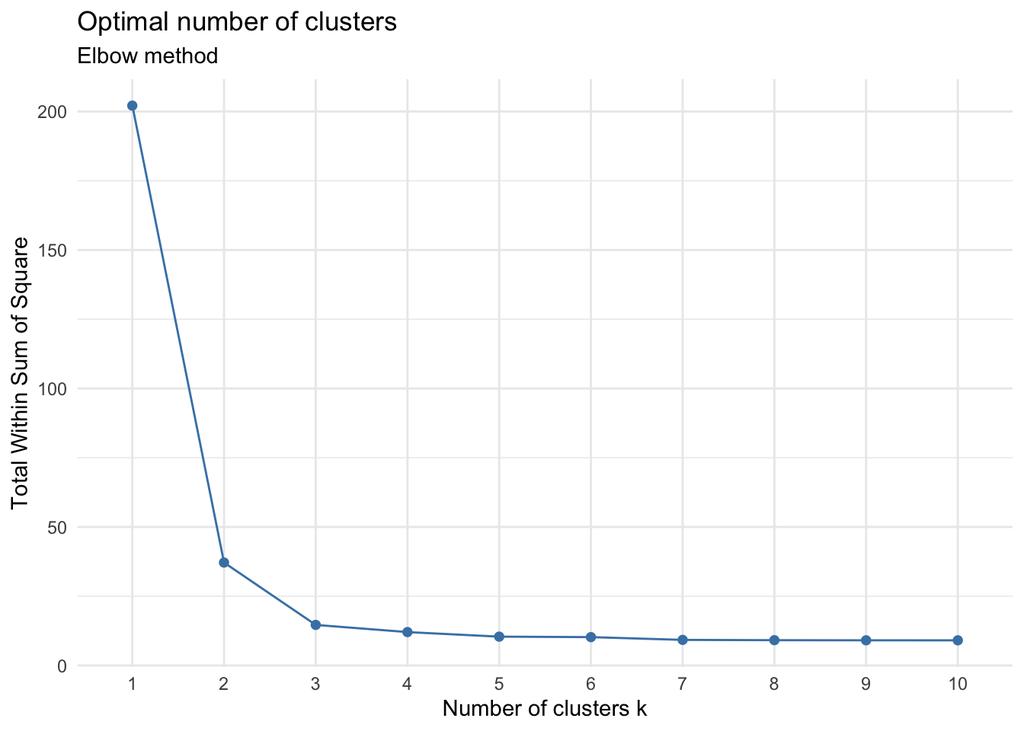

```r
dat_mujeres_t <- t(dat_mujeres)
enf_kmeans_muj <- data.frame(Enfermedades = rownames(dat_mujeres_t))

set.seed(1234)
fviz_nbclust(dat_mujeres_t, kmeans, method = "wss") +
  labs(subtitle = "Elbow method") +
  theme_minimal()
```

```r
kmeans_clust <- kmeans(dat_mujeres_t, centers = 3)
enf_kmeans_muj$clusters<- kmeans_clust$cluster

enf_kmeans_muj <- enf_kmeans_muj[enf_kmeans_muj$Enfermedades %in% muj_100$nodos$`rownames(datos_filtrados)`, ]
```

```r
V(muj_100$grafo)$color <- enf_kmeans_muj$clusters
visIgraph(muj_100$grafo)%>%
  visNodes(font = list(size = 25))
```

[interactive chart not shown]

```r
enfermedades_por_cluster_muj <- aggregate(Enfermedades ~ clusters, data = enf_kmeans_muj, FUN = function(x) paste(x, collapse = ", "))
names(enfermedades_por_cluster_muj) <- c("Cluster", "Enfermedades")
kable(enfermedades_por_cluster_muj, caption = "Enfermedades mujeres por cluster") %>%
  kable_styling(full_width = FALSE) %>%
  column_spec(1, bold = TRUE)
```

Enfermedades mujeres por cluster

| Cluster | Enfermedades |
| --- | --- |
| 1 | Colon cancer, Thyroid cancer, Breast cancer, Ovarian cancer, Hodgkin’s disease, Leukemia, Other organic mental disorder, Alcohol dependence, Psychosis, Other Functional Disorder, Personality and behav… |
| 2 | Dyslipidemia, Anxiety, Hypertension, Osteoarthritis, spondylosis |
| 3 | Hypothyroidism, Obesity, Tobacco dependence, Mood disorder, COPD, Gastroesophageal reflux disease, Osteoporosis, Other arthropathy, Urinary lithiasis |

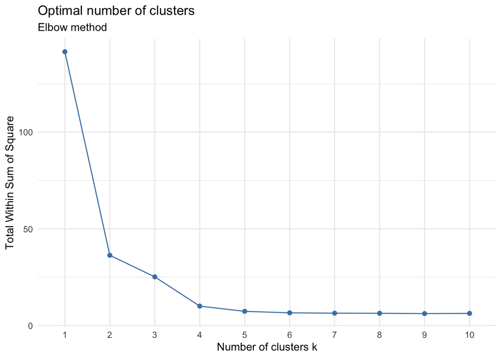

```r
dat_hombres_t <- t(dat_hombres)
enf_kmeans_hom <- data.frame(Enfermedades = rownames(dat_hombres_t))

set.seed(1234)
fviz_nbclust(dat_hombres_t, kmeans, method = "wss") +
  labs(subtitle = "Elbow method") +
  theme_minimal()
```

```r
kmeans_clust <- kmeans(dat_hombres_t, centers = 4)
enf_kmeans_hom$clusters<- kmeans_clust$cluster

enf_kmeans_hom <- enf_kmeans_hom[enf_kmeans_hom$Enfermedades %in% hom_100$nodos$`rownames(datos_filtrados)`, ]
```

```r
V(hom_100$grafo)$color <- enf_kmeans_hom$clusters
visIgraph(hom_100$grafo)%>%
  visNodes(font = list(size = 25))
```

[interactive chart not shown]

```r
enfermedades_por_cluster_hom <- aggregate(Enfermedades ~ clusters, data = enf_kmeans_hom, FUN = function(x) paste(x, collapse = ", "))
names(enfermedades_por_cluster_hom) <- c("Cluster", "Enfermedades")
kable(enfermedades_por_cluster_hom, caption = "Enfermedades hombres por cluster") %>%
  kable_styling(full_width = FALSE) %>%
  column_spec(1, bold = TRUE)
```

Enfermedades hombres por cluster

| Cluster | Enfermedades |
| --- | --- |
| 1 | Alcohol dependence, Mood disorder, Neurological disease with non-stroke motor deficit, Retinopathy, Atrial fibrillation, Heart failure, Liver disease (except cirrhosis), Hepatic steatosis, Gout and ot… |
| 2 | Dyslipidemia, Hypertension |
| 3 | Diabetes, Tobacco dependence, Anxiety, Osteoarthritis, spondylosis |
| 4 | HIV, Hair and neck cancer, Stomach cancer, Colon cancer, Pancreatic cancer, Lung cancer, Bladder cancer, Non-Hodgkin lymphoma, Dementia, Other organic mental disorder, Personality and behavior disorde… |